# Software Tools for Earth and Environmental Science

– 9th WEEK –

Emir Toker

## **R Promgramming - Part 2**

- **Syllabus and Book**
- **Practice - R Programming ( Conditions )**
- **R Programming - *repeat* Loops**
- **R Programming - *while* Loops**
- **R Programming - *for* Loops**
- **R Programming - *apply* groups**

**QUIZ**

- **Next Week**

# **Syllabus and Book**

## **Syllabus**

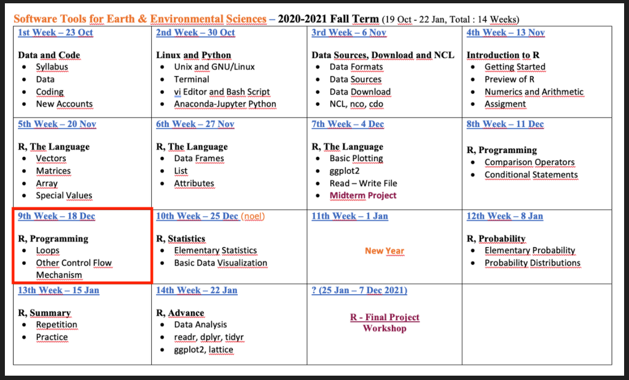

Extended Syllabus [PDF](https://web.itu.edu.tr/~tokerem/Software_Tools_Syllabus.pdf)

## **Book**

[figure not shown]

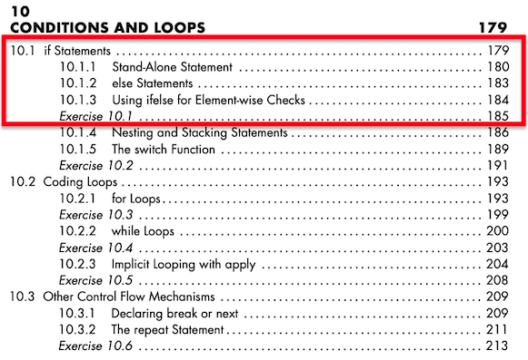

[PDF](https://web.itu.edu.tr/~tokerem/The_Book_of_R.pdf) - (179 - 185)

# **R Language - Repeat**

## **Repeat - R Programming (Conditions)**

- **Comparison Operators**
  - equal (**==**)
  - not equal (**!=**)
  - greater or equal to (**>=**)
  - less or equal to (**<=**)
- **Logical Operators**
  - the *and* operator (**&**)
  - the *or* operator (**|**)
  - the *not* operator (**!**)
- *if* (Stand-Alone) Statement
- *else* Statement
- *else if* Statement

## **R Language - Repeat**

[LINK](https://emirtoker.github.io/Software_Tools_R_Github/r_language.html)

# **R Programming - Conditions**

## **R Programming - Conditions**

- **Comparison Operators**
  - equal (**==**)
  - not equal (**!=**)
  - greater or equal to (**>=**)
  - lower or equal to (**<=**)
- **Logical Operators**
  - the and operator (**&**)
  - the or operator (**|**)
  - the not operator (**!**)
- *if* (Stand-Alone) Statement
- *else* Statement
- *ifelse* Statement

```
TRUE & TRUE
TRUE & FALSE
TRUE | FALSE
!TRUE

2 == 3
5 < 6

c(1,4) >= 6

9 != 8

5 < 6 & 9 != 8
```

```
score <- 80
exam_no <- 2

score >= 75 | exam_no == 1

score>=75 & score<90 | exam_no==1
```

## **Repeat - R Programming (Conditions)**

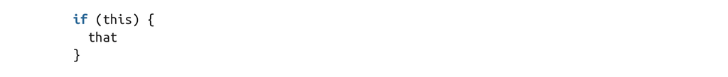

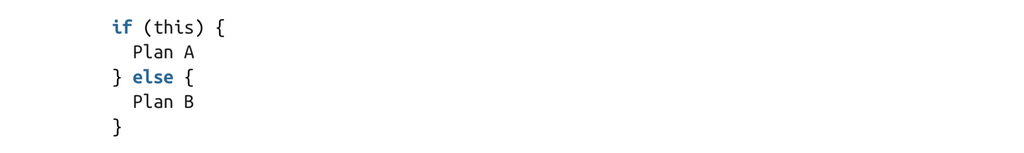

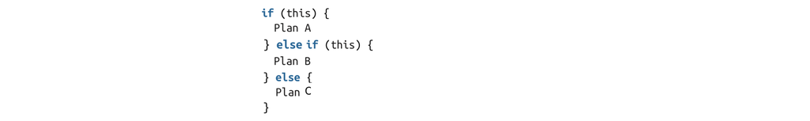

## **Practice I - R Programming (Conditions)**

**Problem** : You want to enjoy at the weekend (“Saturday” or “Sunday”), and let’s say the **day** is;

```r
day <- "Friday"
```

What do you gonna do **if** it is **Friday**.

```
if (...) {
  print('Weekend : Sorry. Lockdown.')
} else {
  print('Do some work.')
}
```

## **Practice I - R Programming (Conditions)**

**Problem** : You want to enjoy at the weekend (“Saturday” or “Sunday”), and let’s say the **day** is;

```r
day <- "Friday"
```

What do you gonna do **if** it is **Friday**.

```
if ( day... | day... ) {
  print('Weekend : Sorry. Lockdown.')
} else {
  print('Do some work.')
}
```

## **Practice I - R Programming (Conditions)**

**ANSWER** : You want to enjoy, and let’s say the day is;

```r
day <- "Friday"
```

It is okay, you can fun **if** it is **weekend**.

```r
if (day == 'Saturday' | day == 'Sunday') {
  print('Weekend : Sorry. Lockdown.')
} else {
  print('Do some work.')
}
```

```
## [1] "Do some work."
```

## **Practice II - R Programming (Conditions)**

**Problem** : You want to go out and your question is

**“Should I take an umbrella?”**

- **Note** : There are two variables in your code,
  - **“sky”** (*character*)
  - **“high_chance_of_rain”** (*logical*)
- Check: if “**sky**” is equal to “**cloudy**” and, is the “**high_chance_of_rain**” TRUE or FALSE
- If both are true, the code should print: **“Take umbrella!”**
- Otherwise, the code should print: **“No need for umbrella!”**
- Based on the condition, what is the answer?

```
RADIO: The sky is cloudy and the chance of rain is high.
```

## **Practice II - R Programming (Conditions)**

Your conditions, for two variables

```
# you want to go out and your question is "Should I take an umbrella?"

sky <-

high_chance_of_rain <-
```

## **Practice II - R Programming (Conditions)**

Your conditions, for two variables

```r
# you want to go out and your question is "Should I take an umbrella?"

sky <- "cloudy"

high_chance_of_rain <- TRUE
```

- Check: if “**sky**” is equal to “**cloudy**” and, is the “**high_chance_of_rain**” TRUE or FALSE
- If both are true, the code should print: **“Take umbrella!”**
- Otherwise, the code should print: **“No need for umbrella!”**

## **Practice II - R Programming (Conditions)**

```r
# you want to go out and your question is "Should I take an umbrella?"

sky <- "cloudy"

high_chance_of_rain <- TRUE
```

```
if (...) {
  print("...")
} else {
  print("...")
  }
```

## **Practice II - R Programming (Conditions)**

```r
# you want to go out and your question is "Should I take an umbrella?"

sky <- "cloudy"

high_chance_of_rain <- TRUE
```

```
if (...) {
  print("Take umbrella!")
} else {
  print("No need for umbrella!")
  }
```

## **Practice II - R Programming (Conditions)**

```r
# you want to go out and your question is "Should I take an umbrella?"

sky <- "cloudy"

high_chance_of_rain <- TRUE
```

```
if ( sky...     &      high_chance_of_rain... ) {
  print("Take umbrella!")
} else {
  print("No need for umbrella!")
  }
```

## **Practice II - R Programming (Conditions)**

```r
# you want to go out and your question is "Should I take an umbrella?"

sky <- "cloudy"

high_chance_of_rain <- TRUE

if (sky == "cloudy" & high_chance_of_rain == TRUE) {
  print("Take umbrella!")
} else {
  print("No need for umbrella!")
  }
```

```
## [1] "Take umbrella!"
```

# **R Programming - Loops**

## **R Programming - Loops**

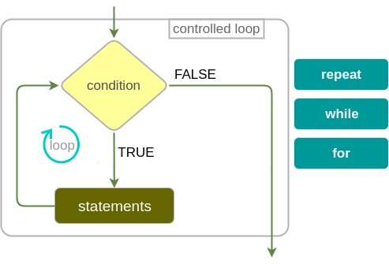

Loops are R’s method for repeating a task, which makes them a useful tool for programming simulations.

# **R Programming - *repeat* Loops**

## **R Programming - *repeat* Loops**

```
repeat
{
  message("Happy Free Day!")
  break
}
```

## **R Programming - *repeat* Loops**

I have 3 COINS and I want to play the game. (So, at first I have 0 GAME)

```
When I started the repeat-loop I want to
  - Reduce (decrease) 1 Coin for each game
  - Enhance (increase) 1 Game for each game
```

## **R Programming - *repeat* Loops**

I have 3 COINS and I want to play the game. (So, at first I have 0 GAME)

```
When I spend my all coins, I want to stop playing game
```

## **R Programming - *repeat* Loops**

```
## Game =1 Nice try, play again
```

```
## Game =2 Nice try, play again
```

```
## Game =3 Nice try, play again
```

## **R Programming - *repeat* Loops**

What if, there is no any break command ?!

```
# Statements previous to repeat loop
coins <- 3
game <- 0

repeat {
# block of statements
  game <- game + 1
  coins <- coins -1

  message("Game =",game, " Nice try, play again")

  # breaking condition
  # there is no any break command !
}
```

```
# use CTRL + C
```

# **R Programming - *while* Loops**

## **R Programming - *while* Loops**

While loops are like backward repeat loops.

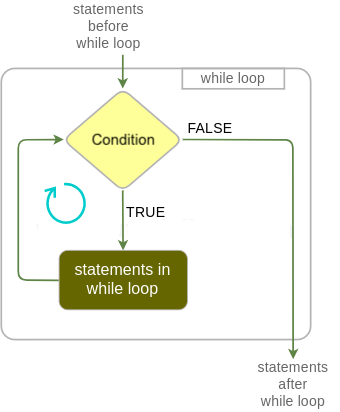

```
## [1] "LOOP"
## [1] "LOOP"
## [1] "LOOP"
## [1] "LOOP"
## [1] "LOOP"
```

```
## [1] 10
```

## **R Programming - *while* Loops**

While loops are like backward repeat loops.

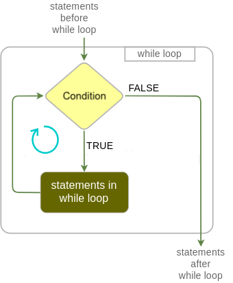

```
## Game = 1 Nice try, play again
```

```
## Game = 2 Nice try, play again
```

```
## Game = 3 Nice try, play again
```

```
## [1] 0 3
```

# **R Programming - *for* Loops**

## **R Programming - *for* Loops**

When you know exactly how many times you want the code to repeat.

```
## [1] 1
## [1] 2
## [1] 3
```

```
## [1] 16
```

## **R Programming - *for* Loops**

When you know exactly how many times you want the code to repeat.

```
## [1] "a"
## [1] "b"
## [1] "c"
```

```
## [1] 16
```

loop is related with the length of the vector !

## **R Programming - *for* Loops**

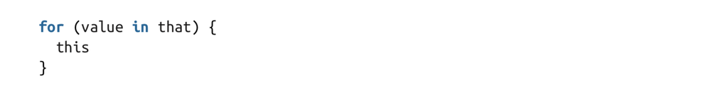

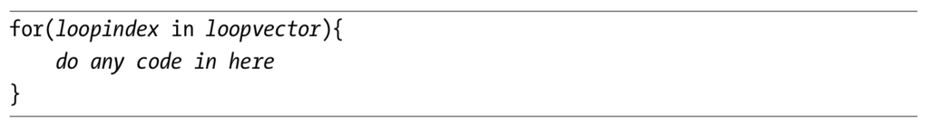

```
## just say it 1 times
```

```
## just say it 2 times
```

## **R Programming - *for* Loops**

When you know exactly how many times you want the code to repeat.

```
## just say it 1 times
```

```
## just say it 2 times
```

```
## just say it apple times
```

```
## just say it banana times
```

*LOOP is related with the length(vector)*

## **R Programming - *for* Loops**

```
##  [1] "January"   "February"  "March"     "April"     "May"       "June"
##  [7] "July"      "August"    "September" "October"   "November"  "December"
```

```
## The month of January
```

```
## The month of February
```

```
## The month of March
```

```
## The month of April
```

```
## The month of May
```

```
## The month of June
```

```
## The month of July
```

```
## The month of August
```

```
## The month of September
```

```
## The month of October
```

```
## The month of November
```

```
## The month of December
```

## **R Programming - *for* Loops**

```
for (i in 1:10) {
  if (i == 2){
    print("i don't use i=2")
    next
  }
  print(i)
}
```

## **R Programming - *for* Loops**

```
## [1] 1
## [1] "i don't use i=2"
## [1] 3
## [1] 4
## [1] 5
## [1] 6
## [1] 7
## [1] 8
## [1] 9
## [1] 10
```

## **R Programming - *for* Loops**

[output not shown]

# **R Programming - *apply* Groups**

## **R Programming - *apply* Groups**

- The **apply()** functions form the basis of more complex combinations and helps to perform operations with very few lines of code.
- More specifically, the family is made up of the **apply()**, **lapply()** , **sapply()**, **vapply()**, **mapply()**, **rapply()**, and **tapply()** functions.

```
apply(X, MARGIN, FUN, ...)

# X is an array or a matrix, dim(X) must have a positive length
# MARGIN=1, it applies over rows, whereas with
# MARGIN=2, it works over columns. Note that when you use the construct
# MARGIN=c(1,2), it applies to both rows and columns
# FUN, which is the function that you want to apply to the data.
```

```
apply(my_matrix, MARGIN=1, mean)
```

## **R Programming - *apply***

```
##             [,1]       [,2]        [,3]      [,4]       [,5]
## [1,]  2.02005688 -0.7510888  0.85241277 0.5159643  0.8189546
## [2,] -0.05705512  0.3836436 -0.08993873 0.4894480  0.1533690
## [3,] -0.57701045  0.4081727 -1.81256234 0.1610991 -0.6685669
```

```
## [1]  0.6912600  0.1758934 -0.4977736
```

```
## [1]  0.46199710  0.01357582 -0.35002943  0.38883714  0.10125224
```

## **R Programming - *apply***

```
##            [,1]       [,2]        [,3]         [,4]        [,5]
## [1,]  0.8610810  1.4086325 -0.06280369 -0.002602994  0.05864157
## [2,]  0.9518314 -0.7794236  0.68562154 -0.340228385 -0.78159277
## [3,] -0.8031686 -1.1291807  0.72255161  0.221269524  0.70444499
```

```
##           [,1]        [,2]        [,3]
## [1,] 0.4525897 -0.05275835 -0.05681664
## [2,] 2.2629484 -0.26379173 -0.28408318
```

## **R Programming - *apply***

```
##         col1       col2        col3
## a -0.2826586  0.6926466  0.05438504
## b  1.0349155 -1.2255437 -0.06929384
## c  1.6882855 -0.3319602  0.68032112
## d -0.4779836  0.4604776  0.52732802
## e  0.4011958 -0.1248847  0.08651011
```

```
## a b c d e
## 1 2 2 1 2
```

## **R Programming - *lapply***

```
## [[1]]
##      [,1] [,2] [,3]
## [1,]    1    4    7
## [2,]    2    5    8
## [3,]    3    6    9
##
## [[2]]
##      [,1] [,2] [,3]
## [1,]    4    8   12
## [2,]    5    9   13
## [3,]    6   10   14
## [4,]    7   11   15
##
## [[3]]
##      [,1] [,2]
## [1,]    8    8
## [2,]    9    9
## [3,]   10   10
```

## **R Programming - *lapply***

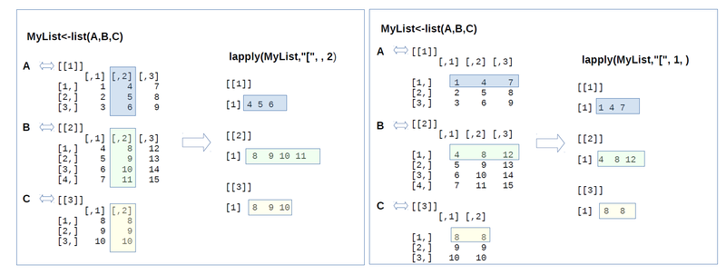

```
## [[1]]
## [1] 4 5 6
##
## [[2]]
## [1]  8  9 10 11
##
## [[3]]
## [1]  8  9 10
```

## **R Programming - *lapply***

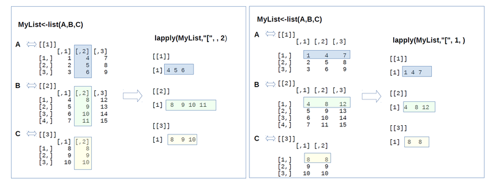

```
## [[1]]
## [1] 1 4 7
##
## [[2]]
## [1]  4  8 12
##
## [[3]]
## [1] 8 8
```

## **R Programming - *sapply* (simplify)**

```
## [[1]]
##      [,1] [,2] [,3]
## [1,]    1    4    7
## [2,]    2    5    8
## [3,]    3    6    9
##
## [[2]]
##      [,1] [,2] [,3]
## [1,]    4    8   12
## [2,]    5    9   13
## [3,]    6   10   14
## [4,]    7   11   15
##
## [[3]]
##      [,1] [,2]
## [1,]    8    8
## [2,]    9    9
## [3,]   10   10
```

```
## [1] 1 4 8
```

```
##      [,1] [,2] [,3]
## [1,]    1    4    8
## [2,]    2    5    9
## [3,]    3    6   10
```

## **R Programming - Conditions**

[LINK](https://emirtoker.github.io/Software_Tools_R_Github/r_programming.html)

# **Next Week**

## **Next Week**

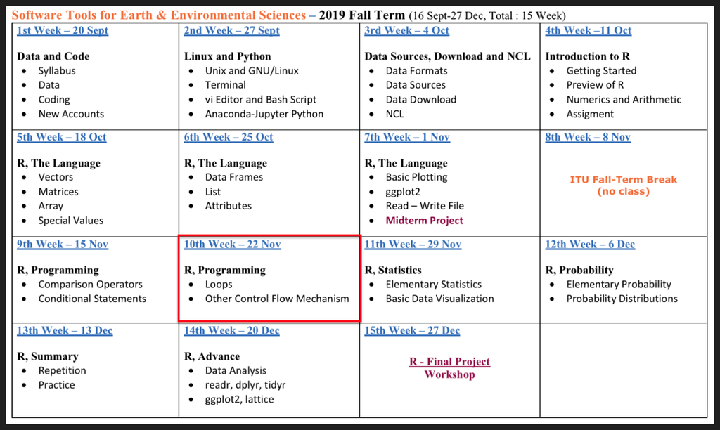

Conditions and Loops, DataCamp

# **(Optional) Practice - MidTerm Project**